# Geometrically Designed Splines: GeDS

Emilio Luis Sáenz Guillén

2026-07-16

## Introduction

GeDS methodology is implemented on the **R** package GeDS that I introduce herein. For a tutorial on the the GAM-GeDS methodology, see [Generalized Additive Models (GAM) with GeD Splines](https://rpubs.com/emilioluissaenzguillen/1209067). For a tutorial focused on FGB-GeDS, see [Functional Gradient Boosting (FGB) with GeD Splines](https://rpubs.com/emilioluissaenzguillen/1341492).

```r
# install.packages("GeDS")
library("GeDS")
```

## What are (polynomial) splines?

A **polynomial spline** is a type of mathematical function made up of several polynomial segments that are “smoothly” joined together at specific points called *knots*. More specifically, a degree-$d$ polynomial spline consists of a piecewise degree-$d$ polynomial function, with continuous $d-1$ first derivatives at each knot. So, for example, a linear spline is obtained by fitting a straight line in each interval that is defined by the knots, requiring continuity at each knot. Similarly, a cubic spline (degree=3) consists of cubic polynomials joined with continuous first and second derivatives at each knot.

Polynomial splines can accommodate a wide range of shapes and are useful for fitting both simple and complex datasets that may not be well-represented by a single polynomial function. Their flexibility arises from the ability to adjust the position and number of knots, allowing for local adjustments to the fitted curve without affecting the entire function.

Polynomial splines are typically represented through a set of basis functions (known as B-splines) spanning the space of the corresponding spline function. This basis representation —also referred to as the B-spline representation—, constitutes a significant advantage since it notably simplifies the mathematical manipulation and computation of these functions. B-splines provide an efficient way to evaluate, differentiate, and integrate polynomial spline functions, facilitating their use in various applications such as computer graphics and computer-aided design, data interpolation and approximation, and regression analysis.

## Normal GeD Spline Regression

Let me start introducing the case of univariate Normal GeDS regression. Consider a response variable $Y$ and a sole independent variable $X$, with $X \in [a, b]$, $a\in\mathbb{R}$, $b\in\mathbb{R}$, and assume there is a relationship between $X$ and $Y$ of the form:
$$\begin{equation}
Y = f(X) + \epsilon
\end{equation}$$
where $f(\cdot)$ is an unknown function and $\epsilon$ is a random normal error variable with zero mean and variance $\mathbb{E}[\epsilon^2]=\sigma_\epsilon^2>0$. In other words, assume $Y|X$ to be normally distributed. A possible solution to the regression problem of estimating $f(\cdot)$ based on a sample of observations $\{X_i, Y_i\}^N_{i=1}$, is to approximate $f$ with an $n$-th order (i.e., degree $n - 1$) spline function that takes values from an interval $[a,b]$ and maps them into $\mathbb{R}$.

Let me now illustrate the usage of the `NGeDS()` function, which constructs a Geometrically Designed (univariate or bivariate) variable knots spline regression model, for a response having a Normal distribution. But first, let us simulate some data based on the following test example. Assume the “true” predictor to be $\eta=f_1(x)$, where,
$$\begin{equation}
f_1(x)=40\frac{x}{1+100x^2}+4,\quad x\in[-2,2].
\end{equation}$$

Based on $f_1(x)$ I generate random samples $\{X_i,Y_i\}_{i=1}^N$ with correspondingly normally distributed response variable, $Y$, and uniformly distributed explanatory variable, $X$. That is, $Y_i\sim N(\mu_i,\sigma)$ with $\sigma=0.2$, $\mu_i=\eta_i=f_1(X_i)$ and $X_i\sim U[-2,2]$, $i=1,...,N$, where $N$ denotes the sample size. For this example, I will consider $N=500$. The **R** implementation of this example is as follows:

```r
# Generate a data sample for the response variable
# Y and the single covariate X
set.seed(123)
N <- 500
f_1 <- function(x) (10*x/(1+100*x^2))*4+4
X <- sort(runif(N, min = -2, max = 2))
# Specify a model for the mean of Y to include only a component
# non-linear in X, defined by the function f_1
means <- f_1(X)
# Add (Normal) noise to the mean of Y
Y <- rnorm(N, means, sd = 0.2)
```

Let us plot our simulated data:

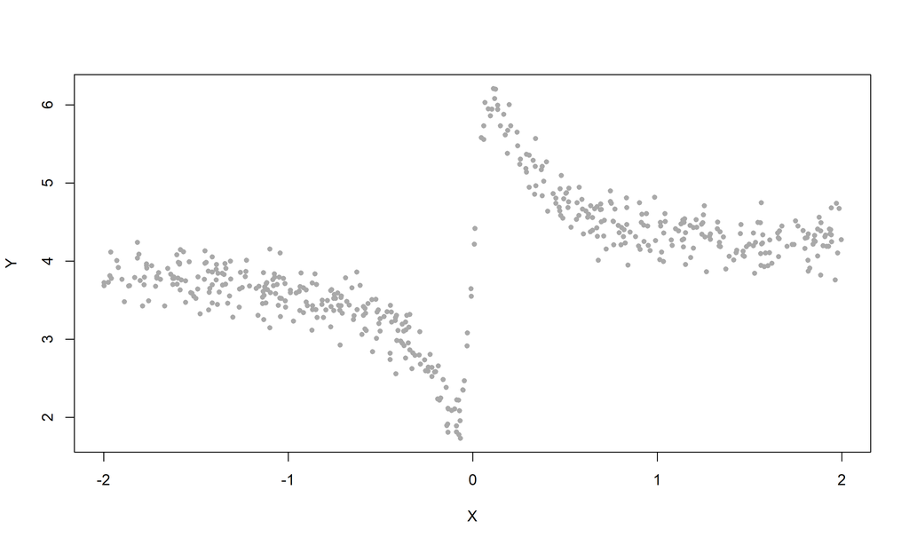

```r
plot(X, Y, pch = 20, col = "darkgrey")
```

A Normal GeDS model is then fit using the `NGeDS()` function. This implements the GeDS regression technique assuming a Normal response variable:

```r
# Fit a Normal GeDS regression using NGeDS
(Gmod <- NGeDS(Y ~ f(X), beta = 0.6, phi = 0.995, Xextr = c(-2,2)))
```

```
##
## Call:
## NGeDS(formula = Y ~ f(X), beta = 0.6, phi = 0.995, Xextr = c(-2,
##     2))
##
## Number of internal knots of the second order (linear) spline: 12
## Deviances:
## Order 2  Order 3  Order 4
##   19.65    19.82    19.57
```

where `beta` and `phi` are tuning parameters and `Xextr` stands for the left-most and right-most limits of the interval embedding the observations of $X$. GeDS algorithm operates through two main stages, **A** and **B**, that I will now briefly explain.

### Stage A

GeDS regression starts by fitting a least-squares (LS) straight line model to the data. After this, the residuals are computed and grouped into clusters based on their sign. Specifically, the first $d_1$ consecutive residuals with the same sign form the first cluster, the next $d_2$ residuals with the same sign form the second cluster, and so on. Weights for these clusters of residuals are then calculated. In the calculation of these weights, the parameter `beta` determines the weight put on the *within-cluster mean residual value*, $m_j$, and the weight put on the *within-cluster* $X$-range, $\eta_j$. The weights, $j$, for each cluster of residuals are given by:
$$\begin{equation}
w_j = \beta \times m'_j + (1 − \beta)\times\eta'_j,\quad j =
1,..., u
\end{equation}$$
where $u$ denotes the total number of clusters of residuals of identical signs, $m'_j=m'_j/m_{max}$ is the normalized within-cluster mean residual value and $\eta'_j=\eta_j/\eta_{max}$ stands for the normalized within-cluster range of the independent variable $X$. A new knot is then inserted in the cluster of residuals that does not already contain a knot and that has the maximal weight $w_j$. The specific location of the new knot is determined by a weighted average of the $X$-coordinates of the residuals in the selected cluster of residuals. For a detailed explanation see [Kaishev et al. 2016](https://link.springer.com/article/10.1007/s00180-015-0621-7).

A LS linear spline fit is then computed including this new knot. Before continuing to a new GeDS iteration a stopping rule consisting on a ratio of consecutive residual sum of squares (RSS) is evaluated:
$$\begin{equation}
\text{RSS}(\kappa+q)/\text{RSS}(\kappa)
=\sum_{i=1}^N(Y_i-\hat{f}\left(\delta_{\kappa+q,2};X_i)\right)^2
\Bigg/ \sum_{j=1}^N\left(Y_i-\hat{f}(\delta_{\kappa,2};X_i)\right)^2
\geq \phi_{\text{exit}}
\end{equation}$$
where $q \geq 1$ and $\phi_{\text{exit}}\in(0,1)$ is a certain pre-specified threshold level close to one. $\boldsymbol{\delta}_{\kappa,2}=\{\delta_1< \delta_2< \delta_3<...<\delta_{\kappa+2}<\delta_{\kappa+3}=\delta_{\kappa+4}\}$ denotes the knots locations, and $\kappa$ the number of internal knots of the linear GeDS fit. In particular, if the ratio of the RSS of the current iteration and the RSS of the `q`th previous iteration is less than `phi`, we continue iterating, starting by fitting a LS linear spline model to the data, with one extra knot. Otherwise, stage A iterations stop.

Stage A fitting process can be visualized as follows:

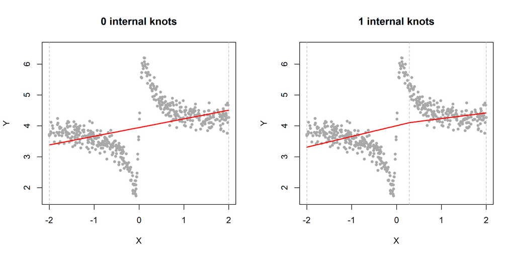

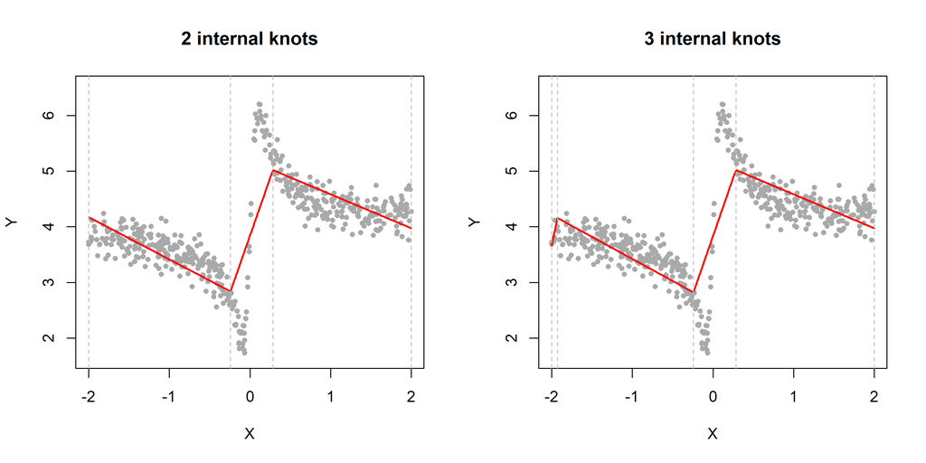

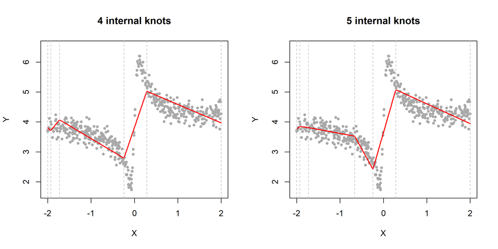

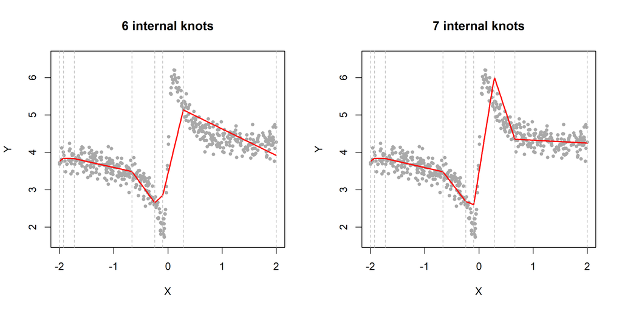

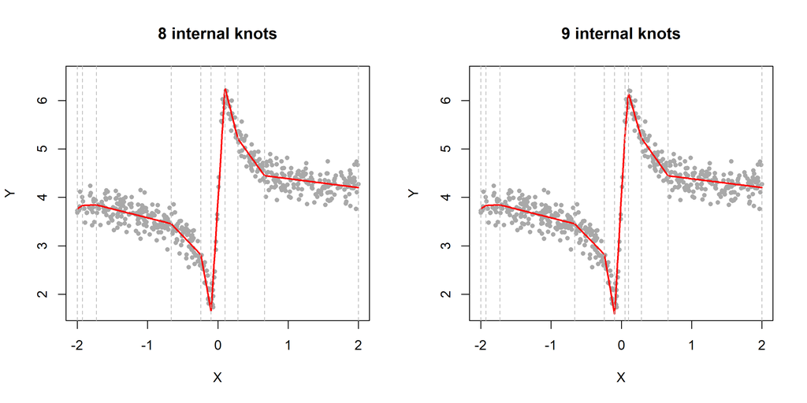

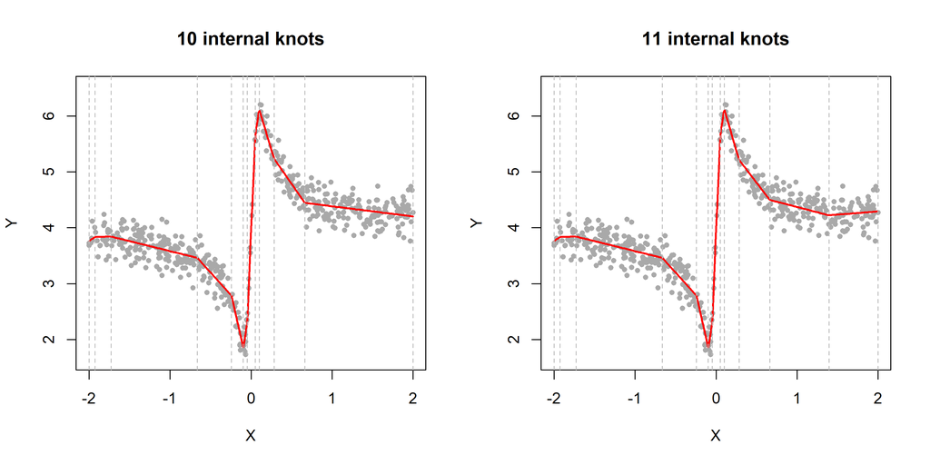

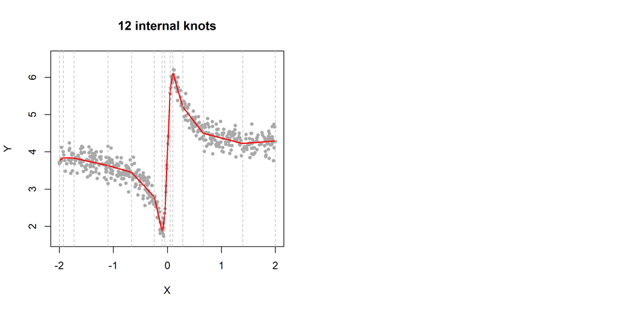

```r
layout(matrix(c(1,2), nrow=1, byrow=TRUE))
plot(Gmod, n = 2, which = 1:(Gmod$Nintknots+1), legend.pos = NA, pch = 20, col = "darkgrey")
```

Argument `which` in `plot.GeDS` allows us to determine the iterations of stage A for which the corresponding GeDS fits should be plotted; `n` specifies the order of the GeDS fit that should be plotted; `n = 2`, means the linear fit is to be plotted. Indeed, stage A pursues a “stick breaking” procedure starting from a straight line fit, that is subsequently broken into smaller linear pieces.

Note that the final stage A GeDS fit is the fit from the $(\kappa + 1)$th iteration, where $\kappa$ denotes the number of internal knots of this fit. This is because the first iteration fit is just a straight line LS fit and then at each GeDS iteration one internal knot is added.

### Stage B

Stage B, begins computing the *averaging knot location*[^1] of the knots vector of the final linear fit obtained via Stage A’s iterations. This is computed for quadratic, and cubic orders; linear averaging knot location coincides with Stage A’s knot location. Secondly, linear, quadratic, and cubic LS spline fits to the data are computed utilizing the corresponding relocated set of knots, thereby completing the GeDS procedure. Note that the final stage A GeDS fit coincides with the final linear GeDS fit.

The final quadratic GeDS fit can be visualized as follows:

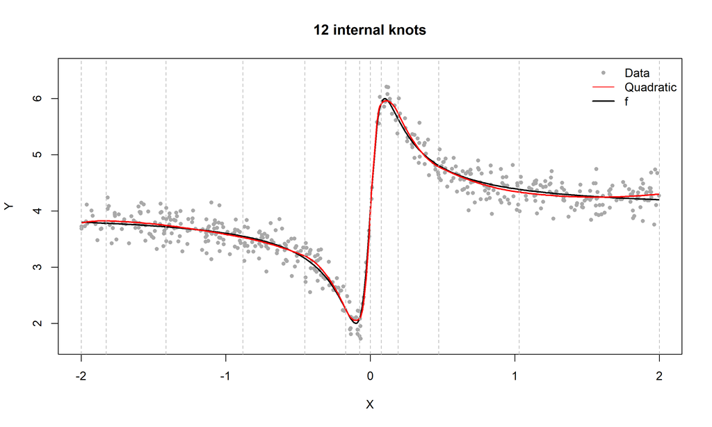

```r
layout(matrix(c(1), nrow=1, byrow=TRUE))
plot(Gmod, f = f_1, n = 3, pch = 20, col = "darkgrey")
```

where the black line depicts the real underlying function $f_1(x)$.

## Generalized GeD Spline Regression

Normal GeDS regression methodology can be extended to the wider context of GNM/GLM models ([Dimitrova et al. 2023](https://doi.org/10.1016/j.amc.2022.127493)).

### The GNM (GLM) fitting problem

Take $Y$ to be a response variable that depends on a single covariate $X$. In a generalized model, we assume that $Y |X$ has a distribution belonging to the *exponential family*. That is, $Y |X$ has a probability density function (continuous case) or probability mass function (discrete case) of the form:
$$\begin{equation}
f(y;\vartheta,\phi) = \exp\left(\frac{y\vartheta −
b(\vartheta)}{a(\phi)}+ c(y,\phi)\right)
\end{equation}$$
where $\vartheta = \vartheta(μ)$ is the so-called *natural parameter* and $\phi$ is the so-called *scale parameter*; $a$, $b$ and $c$ are functions that characterize the distribution. For example, in the Normal case, $\vartheta = \vartheta(\mu)=\mu$, $\phi=\sigma^2$, $a=a(\phi)=\phi$, $b=b(\vartheta)=\frac{\vartheta^2}{2}=\frac{\mu^2}{2}$ and $c=c(y,\phi)=-\frac{1}{2}\left[\frac{y^2}{\sigma^2}+\ln(2\pi\sigma^2)\right]$, and thus, the corresponding density function is:
$$\begin{equation}
f(y;\mu,\sigma^2)=\frac{1}{\sqrt{2\pi\sigma^2}}\exp\left(-\frac{(y-\mu)^2}{2\sigma^2}\right).
\end{equation}$$
The objective is to model the expectation of $Y|X$:
$$\begin{equation}
E\left[Y|X\right]=\mu=g^{-1}(\eta(\boldsymbol{\theta};X))
\end{equation}$$
where $g$ is some *link function* that describes how $\mu$ is connected with the *predictor component* $\eta(\boldsymbol{\theta};X)$. A generalized model is therefore defined by three components:

- a random component, that specifies a distribution for $Y |X$;
- a systematic component, that relates $\eta$ to the predictor(s), $X$;
- and a link function, $g$, that connects the random (the conditional mean $E\left[Y|X\right])$ and systematic components (the linear predictor $\eta(\boldsymbol{\theta};X)$).

Now, we can assume the predictor $\eta(\boldsymbol{\theta}; X)$ to be a polynomial spline function, whose degree, number and location of knots are unknown parameters that we need to estimate. Let us denote by $S_{\boldsymbol{t}_{k,n}}$ the linear space of all $n$th order spline functions defined on a set of non-decreasing knots $\boldsymbol{t}_{k,n} = \{t_i\}^{2n+k}_{i=1}$ , where $t_n = a$, $t_{n+k+1} = b$. We use splines with simple knots, except for the $n$ left and right most knots which will be assumed coalescent, i.e.
$$\begin{equation}
t_{k,n} = \{t_1 = ... = t_n < t_{n+1} < ... < t_{n+k} <
t_{n+k+1} = ... = t_{2n+k}\}
\end{equation}$$
Then, $\eta(\boldsymbol{\theta}; X)$ can be expressed as:
$$\begin{equation}
\eta(\boldsymbol{\theta};X)= f(\boldsymbol{t}_{k,n};
X)=\boldsymbol{\theta}^T\boldsymbol{N}_n(X)=\sum_{i=1}^p\theta_iN_{i,n}(X).
\end{equation}$$
where $f \in S_{\boldsymbol{t}_{k,n}}$, $\left(\boldsymbol{\theta} =\theta_1, ..., \theta_p\right)^T$ is a vector of real valued coefficients and $N_n(x) = \left(N_{1,n}(X), . . ., N_{p,n}(X)\right)^T$, $p = n + k$, are B-splines of order $n$, defined on $t_{k,n}$.

### Generalized GeDS estimation

Now, to estimate the unknown linear predictor function $\eta(\boldsymbol{\theta};X)$ we can use the generalized GeDS method. Indeed, GeDS methodology successfully extends to the more general Exponential Family of distributions in the context of Generalized Non-Linear/Linear Models. Specifically, stage A of Normal GeDS is extended to the more general GNM/GLM context by replacing LS fitting by Iteratively Reweighted Least Squares (IRLS) fitting and the stopping rule by a deviance-based (instead of RSS) stopping criterion.

The usage of function `GGeDS()` is illustrated with the same example as before. Code implemenations and plots are presented as follows.

**Example 1.** The “true” linear predictor is assumed to be $\eta = f_1(x)$, where
$$\begin{equation}
f_1(x) = 40\frac{x}{1 + 100x^2} + 4,\quad x \in [−2, 2].
\end{equation}$$

Random samples, $\{X_i,Y_i\}^N_{i=1}$, are generated with correspondingly Poisson, Gamma and Binomially distributed response variable, $Y$, and uniformly distributed explanatory variable, $X$. That is, $Y_i ∼ \text{Poisson}(\mu_i)$, with $\mu_i = \exp(\eta_i)$ and $\eta_i = f_1(X_i)$; $Y_i ∼ \text{Gamma}(\mu_i, \phi)$ with $\phi = 0.1$, $\mu_i = \exp(\eta_i)$ and $\eta_i = f_1(X_i)$; $Y_i ∼ \text{Binomial}(m,\mu_i)$ with $m = 50$, $\mu_i = \exp(\eta_i)/(1 + \exp(\eta_i))$, $\eta_i = f_1(X_i) − 4$; and $X_i \sim U[−2, 2]$, $i = 1, ..., N$, where $N=500$ is the sample size.

```r
# Generate a data sample for the response variable Y and the covariate X
# See section 4.1 in Dimitrova et al. (2023)
set.seed(123)
N <- 500
f_1 <- function(x) (10*x/(1+100*x^2))*4+4
X <- sort(runif(N, min = -2, max = 2))
# Specify a model for the mean of Y to include only a component
# non-linear in X, defined by the function f_1
means <- exp(f_1(X))
```

#### Poisson:

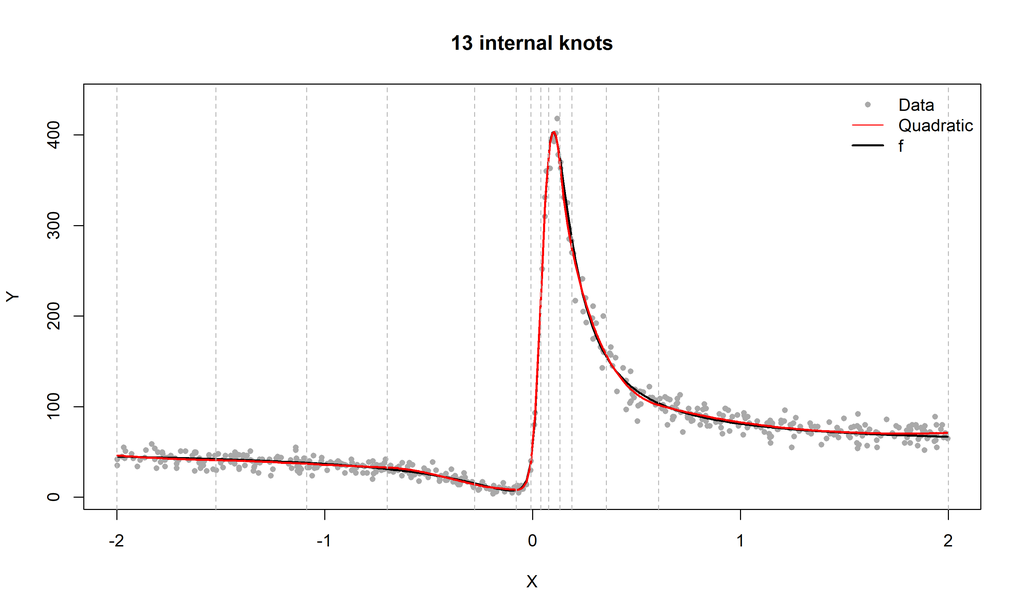

```r
#########################################
## (A) Y ~ Poisson + log link function ##
#########################################
# Generate Poisson distributed Y according to the mean model
Y <- rpois(N, means)
# Fit a Poisson GeDS regression using GGeDS
Gmod <- GGeDS(Y ~ f(X), beta = 0.2, phi = 0.995, family = "poisson",
              Xextr = c(-2,2))
plot(Gmod, f = function(x) exp(f_1(x)), n = 3, pch = 20, col = "darkgrey")
```

#### Gamma:

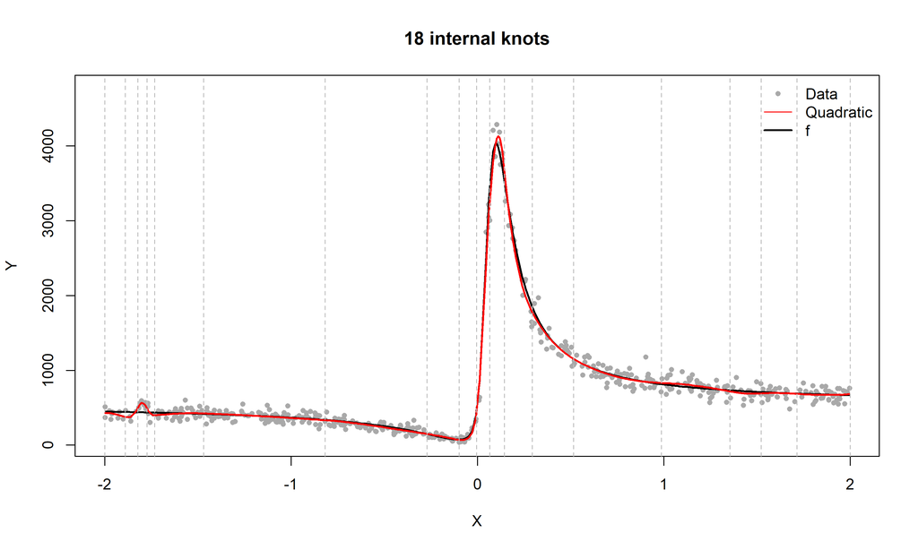

```r
#######################################
## (B) Y ~ Gamma + log link function ##
#######################################
# Generate Gamma distributed Y according to the mean model
Y <- rgamma(N, shape = means, rate = 0.1)
# Fit a Gamma GeDS regression using GGeDS
Gmod <- GGeDS(Y ~ f(X), beta = 0.1, phi = 0.995, family =  Gamma(log),
              Xextr = c(-2,2))
plot(Gmod, f = function(x) exp(f_1(x))/0.1, n = 3, pch = 20, col = "darkgrey")
```

#### (Quasi)Binomial:

While the binomial distribution is used for modeling binary data with fixed success probabilities (e.g., success/failure, yes/no, 0/1) and independent trials, the quasibinomial distribution accommodates scenarios where the probability of success may vary across trials, and does not strictly adhere to a fixed probability of success for each trial. In particular, it is used for binary outcome data that exhibit so-called *overdispersion*, which occurs when the observed variance is greater than what the binomial distribution predicts. This variance flexibility provided by the quasibinomial distribution allows for a more adaptable approach to modeling binary outcome data.

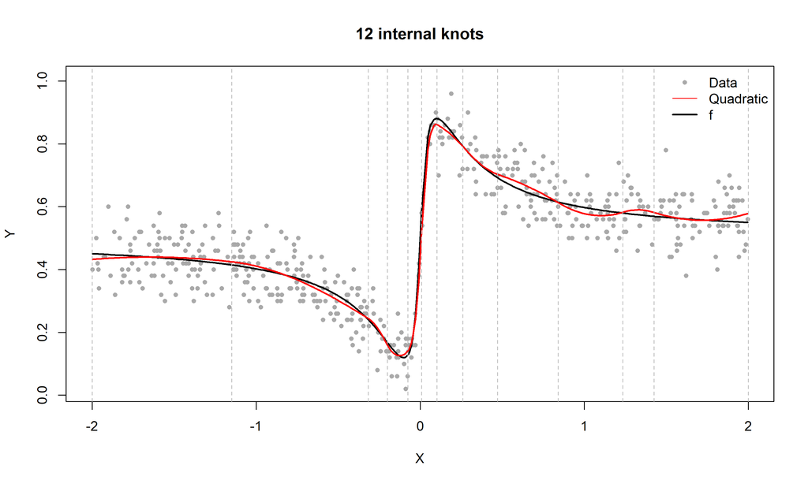

```r
############################################
## (C) Y ~ Binomial + logit link function ##
############################################
# Generate Binomial distributed Y according to the mean model
eta <- f_1(X) - 4
means <- exp(eta)/(1+exp(eta))
Y <- rbinom(N, size = 50, prob = means) / 50
# Fit a Binomial GeDS regression using GGeDS
Gmod <- GGeDS(Y ~ f(X), beta = 0.1, phi = 0.995, family =  "binomial",
              Xextr = c(-2,2))
plot(Gmod, f = function(x) exp(f_1(x) - 4)/(1 + exp(f_1(x) - 4)),
     n = 3, pch = 20, col = "darkgrey")
```

## Bivariate GeD Spline Regression

Similar to the univariate case, bivariate GeDS regression starts applying the IRLS procedure to find a bivariate linear spline fit $\hat{f}(\Delta_{k_1\times k_2},\hat{\alpha}_p; x)$ with zero internal knots (i.e. a bivariate linear model). Subsequently, a stopping rule based on the deviances at consecutive iterations is checked and, if fulfilled, we move to stage B. Otherwise, a new knot in the $X_1=X$ or $X_2=Y$ direction is added. This is done by identifying a potential new knot $\delta^*$ for each direction, $X_1=X$ and $X_2=Y$, based on the univariate GeDS procedure (GeDS). Then, the knot with maximal *within-cluster mean residual/within-cluster range*-weight is added.

Below, the implementation of Normal bivariate GeDS and Poisson bivariate GeDS, with `NGeDS()` and `GGeDS()` functions, respectively, is illustrated. In particular the following example is considered:

**Example 2.** The “true” linear predictor is assumed to be $\eta = f(x_1,x_2)$, where
$$\begin{equation}
f(x_1,x_2) = \sin(2x_1)\sin(2x_2),\quad x \in [0, 3]^2.
\end{equation}$$

#### Normal Bivariate GeDS:

```r
# bivariate example
# See Dimitrova et al. (2023), section 5

# Generate a data sample for the response variable
# Z and the covariates X and Y assuming Normal noise
set.seed(123)
doublesin <- function(x){
 sin(2*x[,1])*sin(2*x[,2])
}

X <- (round(runif(400, min = 0, max = 3),2))
Y <- (round(runif(400, min = 0, max = 3),2))
Z <- doublesin(cbind(X,Y))
Z <- Z + rnorm(400, 0, sd = 0.2)
# Fit a two dimensional GeDS model using NGeDS
(BivGeDS <- NGeDS(Z ~ f(X, Y), beta = 0.3, phi = 0.95,
Xextr = c(0, 3), Yextr = c(0, 3)))
```

```
##
## Call:
## NGeDS(formula = Z ~ f(X, Y), beta = 0.3, phi = 0.95, Xextr = c(0,
##     3), Yextr = c(0, 3))
##
## Number of internal knots of the second order (linear) spline in the X direction: 4
## Number of internal knots of the second order (linear) spline in the Y direction: 2
##
##
## Deviances:
## Order 2  Order 3  Order 4
##   16.40    15.06    15.72
```

```r
# Extract quadratic coefficients/knots/deviance
coef(BivGeDS, n = 3)
```

```
##           N1           N2           N3           N4           N5           N6
##  0.282385872 -0.487118611  0.444703313 -0.088829996 -0.446377161  4.011455138
##           N7           N8           N9          N10          N11          N12
## -3.535054732 -0.586631965  0.276339720 -1.365408778  1.127125376  0.186682548
##          N13          N14          N15          N16          N17          N18
##  0.167833476 -2.244551356  2.043918655  0.163488019  0.008762613 -1.206936957
##          N19          N20          N21          N22          N23          N24
##  1.046602983  0.505856296  0.187959217 -0.430279662  0.594978746  0.161764412
```

```r
knots(BivGeDS, n = 3)
```

```
## $Xk
## [1] 0.000000 0.000000 0.000000 1.484216 2.201172 2.582761 3.000000 3.000000
## [9] 3.000000
##
## $Yk
## [1] 0.000000 0.000000 0.000000 1.558032 3.000000 3.000000 3.000000
```

```r
deviance(BivGeDS, n = 3)
```

```
## [1] 15.06419
```

```r
# RSS w.r.t true function
f_XY <- apply(cbind(X, Y), 1, function(row) doublesin(matrix(row, ncol = 2)))
mean((f_XY- Gmod$Quadratic.Fit$Predicted)^2)
```

```
## [1] NaN
```

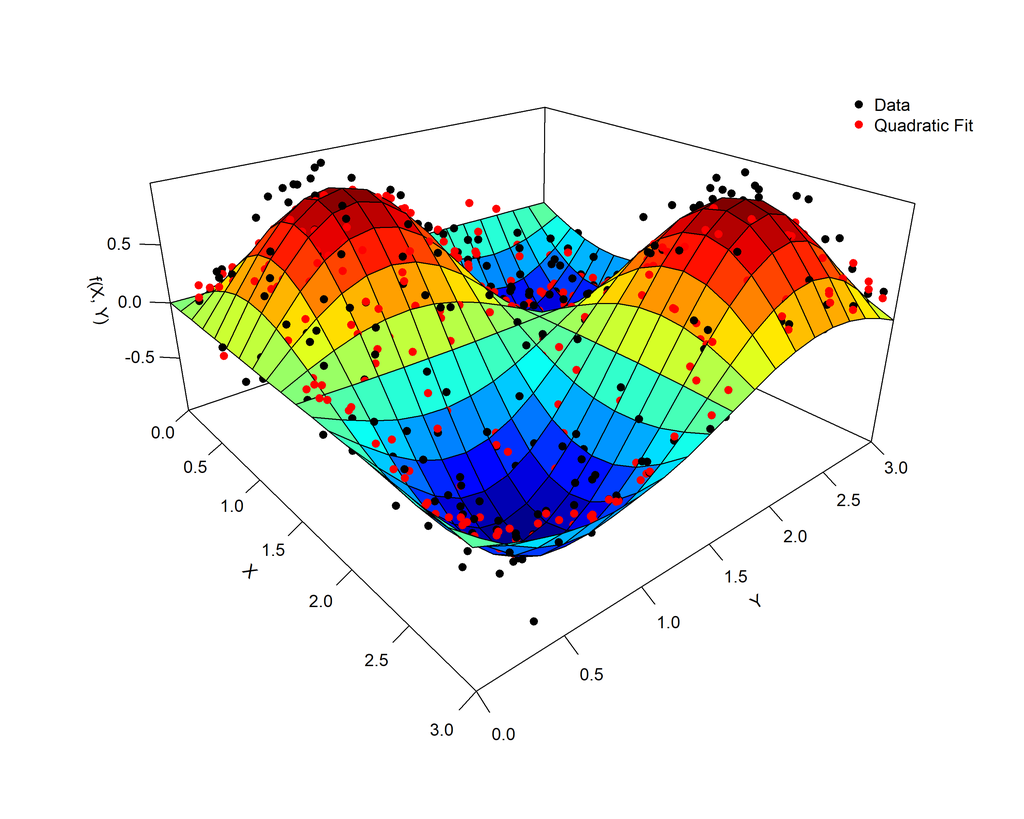

```r
# Surface plot of the generating function (doublesin)
plot(BivGeDS, f = doublesin)
```

#### Poisson Bivariate GeDS:

```r
# bivariate example
# See Dimitrova et al. (2023), section 5

# Generate a data sample for the response variable
# Z and the covariates X and Y assuming Poisson distributed error
set.seed(123)
doublesin <- function(x) {
# Adjusting the output to ensure it's positive
exp(sin(2*x[,1]) + sin(2*x[,2]))
}
X <- round(runif(400, min = 0, max = 3), 2)
Y <- round(runif(400, min = 0, max = 3), 2)
# Calculate lambda for Poisson distribution
lambda <- doublesin(cbind(X,Y))
# Generate Z from Poisson distribution
Z <- rpois(400, lambda)
data <- data.frame(X, Y, Z)

# Fit a Poisson GeDS regression using GGeDS
(BivGeDS <- GGeDS(Z ~ f(X,Y), beta = 0.2, phi = 0.99, family = "poisson"))
```

```
##
## Call:
## GGeDS(formula = Z ~ f(X, Y), family = "poisson", beta = 0.2,
##     phi = 0.99)
##
## Number of internal knots of the second order (linear) spline in the X direction: 2
## Number of internal knots of the second order (linear) spline in the Y direction: 3
##
##
## Deviances:
## Order 2  Order 3  Order 4
##   395.0    374.9    369.5
```

```r
# Extract quadratic coefficients/knots/deviance
coef(BivGeDS, n = 3)
```

```
##          N1          N2          N3          N4          N5          N6
##  0.47672488  0.42434037  1.72296364 -2.60192925 -1.32557066  1.86075750
##          N7          N8          N9         N10         N11         N12
##  2.44174219  2.96121255  0.08818689  1.45855969 -1.19964500 -1.34227884
##         N13         N14         N15         N16         N17         N18
## -0.10490406 -2.17346768 -2.33661806 -1.95972137  0.07035776  1.23881825
##         N19         N20
## -3.78690000 -1.85562706
```

```r
knots(BivGeDS, n = 3)
```

```
## $Xk
## [1] 0.000000 0.000000 0.000000 1.344566 3.000000 3.000000 3.000000
##
## $Yk
## [1] 0.0000000 0.0000000 0.0000000 0.4704505 1.4338926 2.9900000 2.9900000
## [8] 2.9900000
```

```r
deviance(BivGeDS, n = 3)
```

```
## [1] 374.9047
```

```r
# Poisson deviance w.r.t true function
f_XY <- apply(cbind(X, Y), 1, function(row) doublesin(matrix(row, ncol = 2)))
sum(poisson()$dev.resids(f_XY, BivGeDS$Quadratic.Fit$Predicted, wt = 1))
```

```
## [1] NA
```

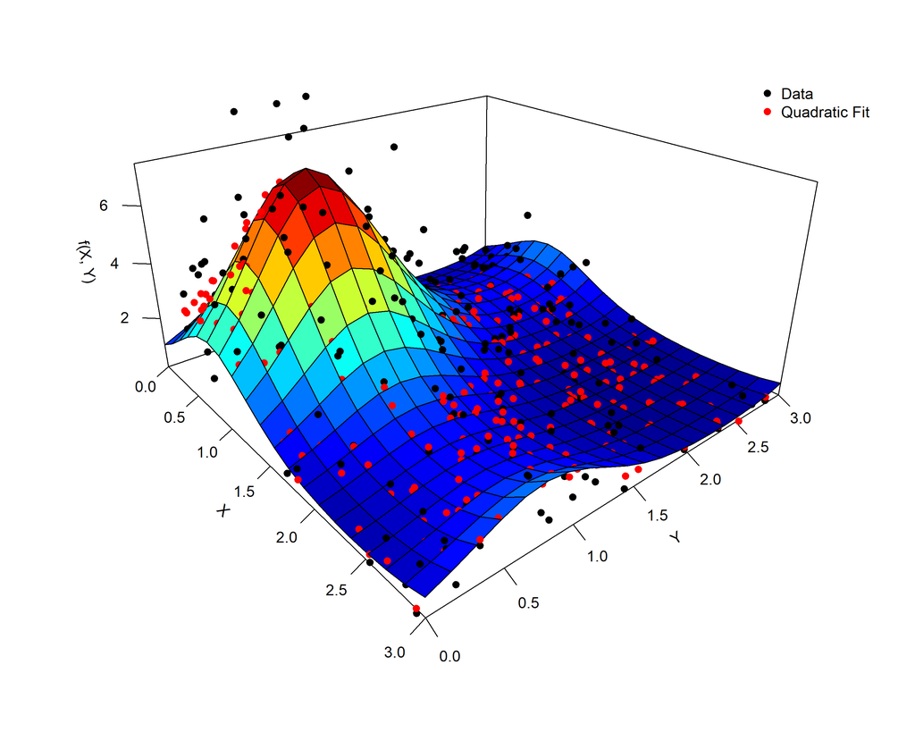

```r
# Surface plot of the generating function (doublesin)
plot(BivGeDS, f = doublesin)
```

Dimitrova, D. S., Kaishev, V. K., Lattuada, A., & Verrall, R. J. (2023). Geometrically designed variable knot splines in generalized (non-)linear models. *Applied Mathematics and Computation*, *436*. https://doi.org/10.1016/j.amc.2022.127493

Kaishev, V. K., Dimitrova, D. S., Haberman, S., & Verrall, R. J. (2016). Geometrically designed, variable knot regression splines. *Computational Statistics*, *31*(3), 1079–1105. https://doi.org/10.1007/s00180-015-0621-7

[^1]: See [Kaishev et al. 2016](https://link.springer.com/article/10.1007/s00180-015-0621-7) for details.